# Publication-Ready Tables, Figures, and Reports

mixedFlowR tutorial series

# 1 Purpose

A statistically correct model can still be communicated poorly. This vignette presents `mixedFlowR` as a communication layer that converts fitted model objects into tidy numerical tables, observed-data figures, model-based curves, residual plots, random-effect displays, covariance heat maps, spatial surfaces, bootstrap plots, and reproducible report skeletons.

The central principle is that the **data-frame result remains authoritative**. Formatting does not change estimates.

# 2 1. Learning objectives

You will learn to:

- create fixed-effect and variance-component tables;
- render Markdown, LaTeX, HTML, and Word-ready tables;
- create raw-data, residual, fixed-effect, random-effect, curve, covariance, bootstrap, and spatial plots;
- show observed data together with estimates;
- export 600 dpi raster and vector graphics;
- distinguish estimates from uncertainty and raw data;
- create a reproducible report skeleton.

# 3 2. Fit a working model

```r
library(mixedFlowR)
z <- mixed_data("longitudinal")

if (requireNamespace("lme4", quietly = TRUE)) {
  fit <- mixed_fit(
    height ~ treatment * time + (time | subject),
    data = z
  )
}
```

# 4 3. Authoritative fixed-effect table

```r
if (exists("fit")) {
  tab_fixed <- mixed_table(
    fit,
    component = "fixed",
    format = "data.frame"
  )

  tab_fixed
}
```

```
#>               term   estimate std.error
#> 1      (Intercept) 16.8336323 0.7413319
#> 2      treatmentT2  1.4381116 1.0484016
#> 3             time  2.0196431 0.1545094
#> 4 treatmentT2:time  0.4899707 0.2185093
```

This data frame is the numerical source for downstream formatting.

# 5 4. Markdown table

```r
if (
  exists("fit") &&
  requireNamespace("knitr", quietly = TRUE)
) {
  mixed_table(
    fit,
    component = "fixed",
    format = "markdown",
    digits = 3,
    caption = "Fixed-effect estimates"
  )
}
```

Fixed-effect estimates

| term | estimate | std.error |
| --- | --- | --- |
| (Intercept) | 16.834 | 0.741 |
| treatmentT2 | 1.438 | 1.048 |
| time | 2.020 | 0.155 |
| treatmentT2:time | 0.490 | 0.219 |

# 6 5. Random-effect variance table

```r
if (
  exists("fit") &&
  requireNamespace("knitr", quietly = TRUE)
) {
  mixed_table(
    fit,
    component = "random",
    format = "markdown",
    digits = 3,
    caption = "Random-effect variance components"
  )
}
```

Random-effect variance components

| grp | var1 | var2 | vcov | sdcor |
| --- | --- | --- | --- | --- |
| subject | (Intercept) | NA | 7.583 | 2.754 |
| subject | time | NA | 0.286 | 0.535 |
| subject | (Intercept) | time | -0.029 | -0.020 |
| Residual | NA | NA | 1.261 | 1.123 |

# 7 6. ANOVA table

```r
if (
  exists("fit") &&
  requireNamespace("knitr", quietly = TRUE)
) {
  mixed_table(
    fit,
    component = "anova",
    format = "markdown",
    digits = 3,
    caption = "Model ANOVA table"
  )
}
```

Model ANOVA table

|  | npar | Sum Sq | Mean Sq | F value |
| --- | --- | --- | --- | --- |
| treatment | 1 | 3.464 | 3.464 | 2.747 |
| time | 1 | 541.825 | 541.825 | 429.649 |
| treatment:time | 1 | 6.341 | 6.341 | 5.028 |

Always describe the denominator-DF and testing framework separately when relevant; a formatted table does not encode all inferential context.

# 8 7. Estimated marginal means table

```r
if (
  exists("fit") &&
  requireNamespace("emmeans", quietly = TRUE) &&
  requireNamespace("knitr", quietly = TRUE)
) {
  mixed_table(
    fit,
    component = "emmeans",
    format = "markdown",
    specs = ~ treatment,
    caption = "Estimated marginal means by treatment"
  )
}
```

Estimated marginal means by treatment

| treatment | emmean | SE | df | lower.CL | upper.CL |
| --- | --- | --- | --- | --- | --- |
| T1 | 21.883 | 0.793 | 28 | 20.258 | 23.507 |
| T2 | 24.546 | 0.793 | 28 | 22.921 | 26.170 |

# 9 8. Word-ready flextable

```r
if (
  exists("fit") &&
  requireNamespace("flextable", quietly = TRUE)
) {
  ft <- mixed_table(
    fit,
    component = "fixed",
    format = "flextable",
    digits = 3,
    caption = "Fixed-effect estimates"
  )

  ft
}
```

Fixed-effect estimates

| term | estimate | std.error |
| --- | --- | --- |
| (Intercept) | 16.834 | 0.741 |
| treatmentT2 | 1.438 | 1.048 |
| time | 2.020 | 0.155 |
| treatmentT2:time | 0.490 | 0.219 |

This object can be inserted into a Word-oriented reporting workflow.

# 10 9. Raw-data plot

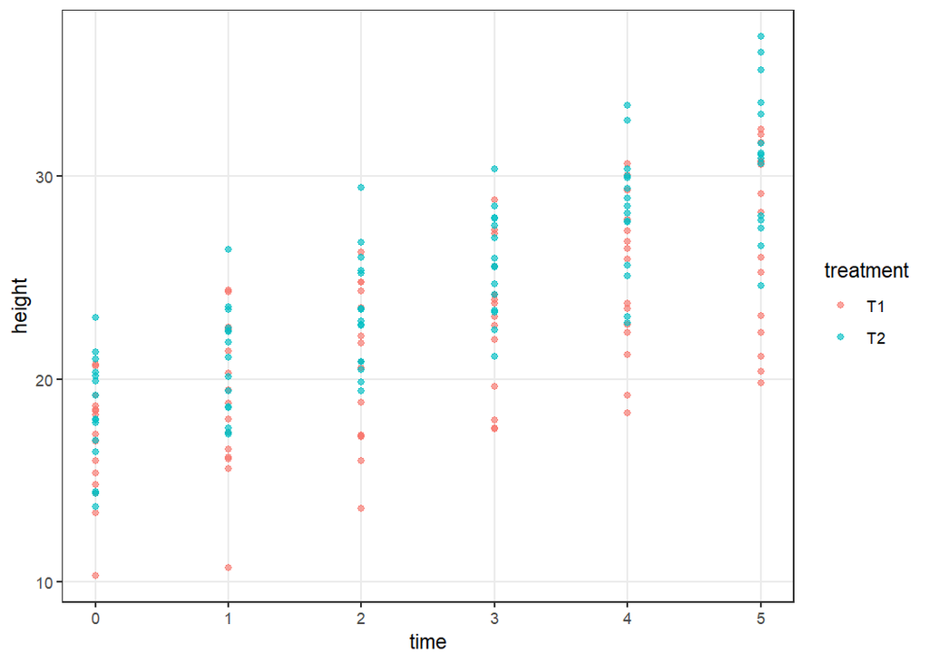

```r
if (exists("fit")) {
  mixed_plot(
    fit,
    type = "raw",
    x = "time",
    by = "treatment"
  )
}
```

Observed-data plots should appear early in an analysis because they reveal features that summary tables can hide.

# 11 10. Residual diagnostic plot

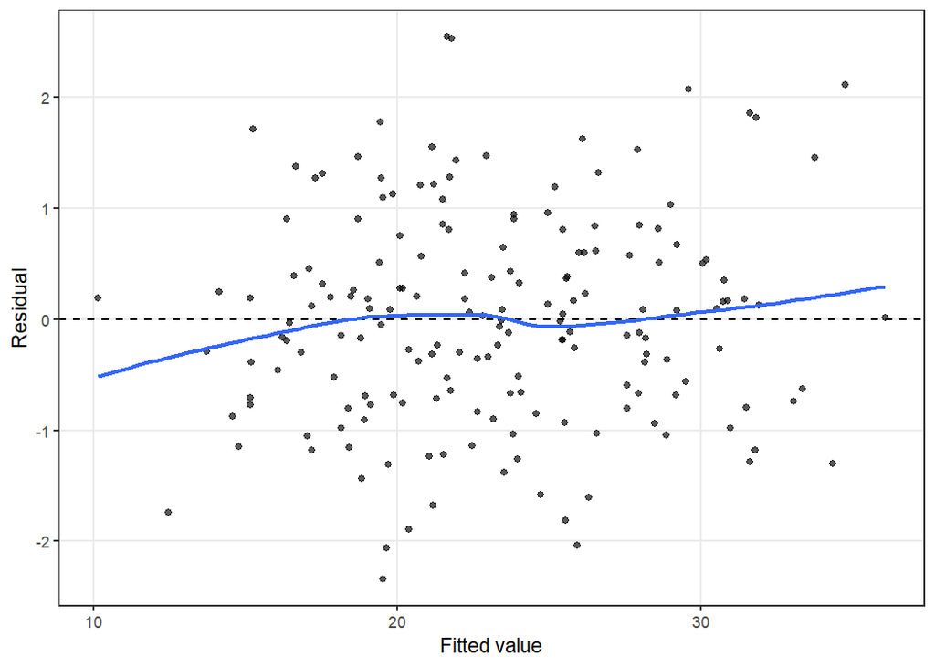

```r
if (exists("fit")) {
  mixed_plot(fit, type = "residuals")
}
```

The smoothed residual trend is a visual aid. It is not a formal goodness-of-fit test.

# 12 11. Fixed-effect interval plot

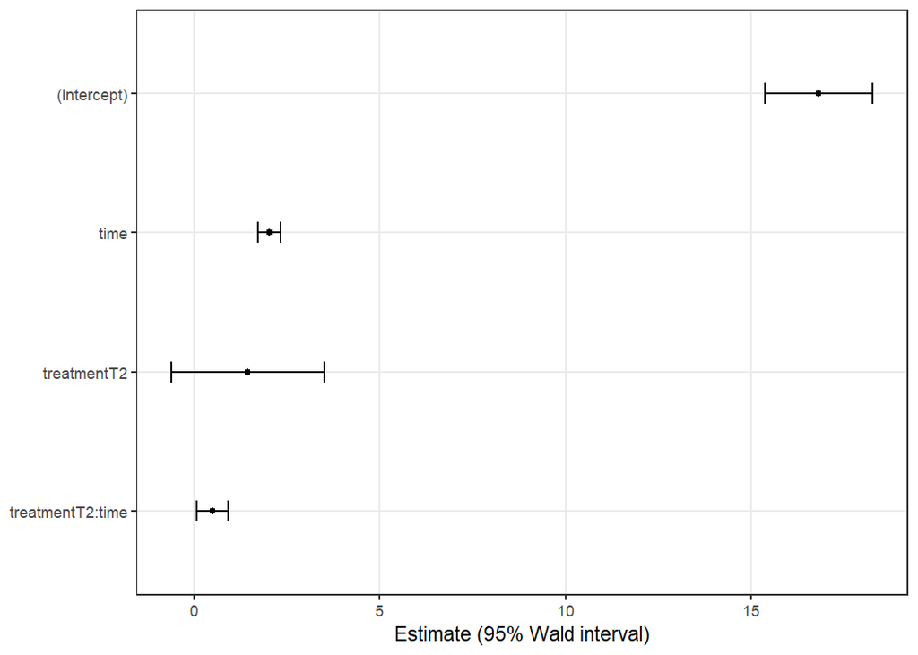

```r
if (exists("fit")) {
  mixed_plot(fit, type = "fixed")
}
```

The current communication layer uses approximate 95% Wald intervals where standard errors are available. Label the interval method accurately in manuscripts.

# 13 12. Random-effect plot

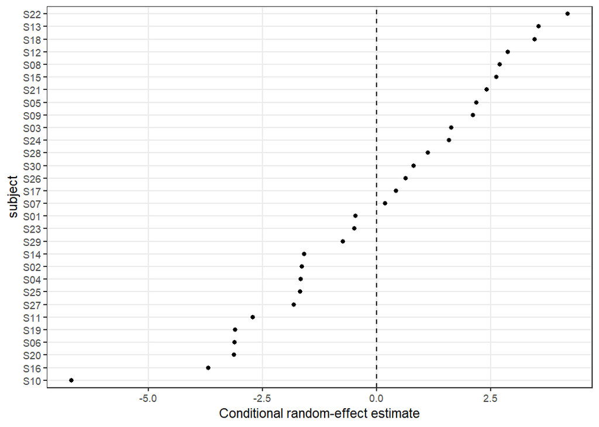

```r
if (exists("fit")) {
  mixed_plot(fit, type = "random")
}
```

A random-effect plot shows conditional deviations, not treatment means.

# 14 13. Response curves with observed data

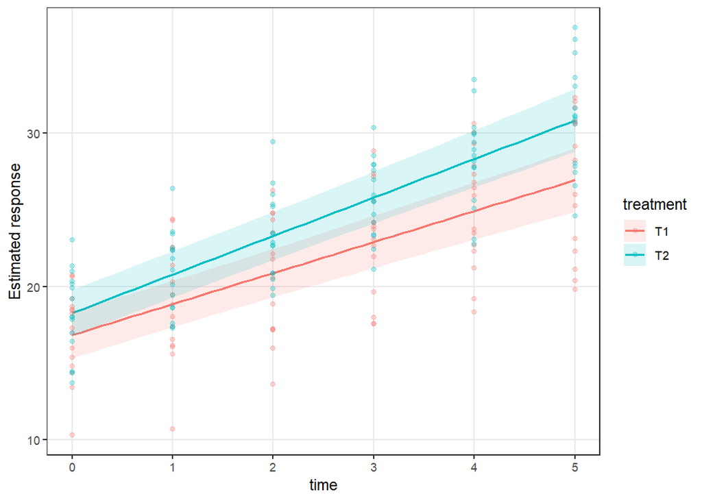

```r
if (
  exists("fit") &&
  requireNamespace("emmeans", quietly = TRUE)
) {
  mixed_plot(
    fit,
    type = "curve",
    x = "time",
    by = "treatment",
    values = seq(min(z$time), max(z$time), by = 0.1),
    show_data = TRUE
  )
}
```

**Figure principle:** show the observed data and uncertainty whenever possible. The model should not visually erase the data-generating evidence.

# 15 14. Covariance heat map

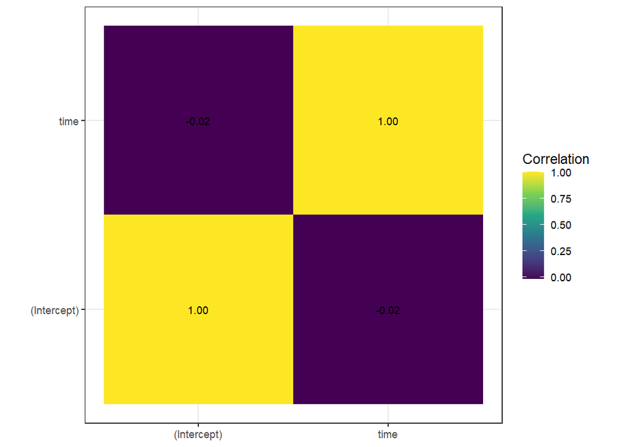

```r
if (exists("fit")) {
  mixed_plot(
    fit,
    type = "covariance",
    group = "subject",
    correlation = TRUE
  )
}
```

Caption this as the estimated **random-effect** correlation/covariance unless the plotted object specifically represents residual covariance.

# 16 15. Bootstrap figure

```r
if (requireNamespace("lme4", quietly = TRUE)) {
  fit_ri <- mixed_fit(height ~ treatment * time + (1 | subject), z)
  boot_demo <- mixed_boot_fixed(fit_ri, B = 49, seed = 260818)
}
```

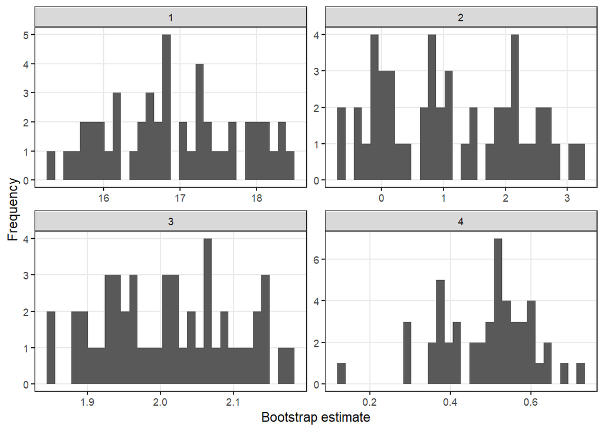

```r
if (exists("boot_demo")) {
  mixed_plot(boot_demo, type = "bootstrap")
}
```

# 17 16. Spatial figure

```r
s <- mixed_data("spatial")

if (requireNamespace("SpATS", quietly = TRUE)) {
  sp <- mixed_spatial_field(
    s,
    "yield",
    "genotype",
    "col",
    "row",
    random = ~ block
  )
}
```

[output not shown]

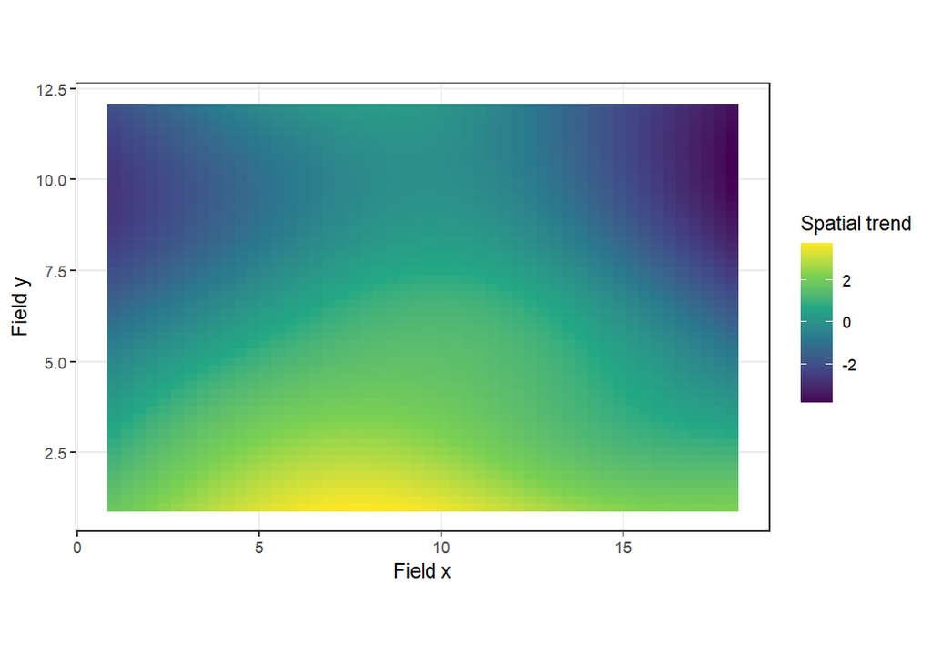

```r
if (exists("sp")) {
  mixed_plot(sp, type = "spatial")
}
```

# 18 17. Export raster figures at 600 dpi

```r
mixed_plot(
  fit,
  type = "residuals",
  file = "residual_diagnostics.tiff",
  width = 7,
  height = 5,
  dpi = 600
)
```

TIFF is useful for journals that request high-resolution raster figures.

# 19 18. Export vector figures

```r
mixed_plot(
  fit,
  type = "fixed",
  file = "fixed_effects.svg",
  width = 7,
  height = 5
)
```

```r
mixed_plot(
  fit,
  type = "curve",
  x = "time",
  by = "treatment",
  values = seq(0, 5, by = 0.1),
  file = "treatment_curves.pdf",
  width = 7,
  height = 5
)
```

Vector formats preserve line and text quality during resizing.

# 20 19. Why isolated bar charts are discouraged

For continuous responses, a bar plus standard error hides:

- distribution shape;
- sample density;
- outliers;
- heteroscedasticity;
- overlap among groups;
- within-group variation.

Prefer observed points, distributions, model curves, or interval plots.

# 21 20. Figure captions should identify the estimand

A good caption distinguishes among:

- raw observations;
- fitted conditional values;
- population-level estimates;
- EMMs;
- confidence or credible intervals;
- posterior predictive distribution;
- spatial trend;
- random effects.

Do not call every model-derived line a “regression line” without explaining what it represents.

# 22 21. Generate a report skeleton

Use a temporary file for an evaluated demonstration.

```r
if (exists("fit")) {
  tmp_report <- tempfile(fileext = ".md")
  mixed_report(
    fit,
    file = tmp_report,
    title = "Longitudinal mixed-model analysis"
  )

  readLines(tmp_report, n = 12)
}
```

```
#>  [1] "# Longitudinal mixed-model analysis"
#>  [2] ""
#>  [3] "Generated: 2026-08-18 23:54:57.400056"
#>  [4] "Engine: `lme4`"
#>  [5] ""
#>  [6] "## Model specification"
#>  [7] ""
#>  [8] "Call: `mixed_fit(formula = height ~ treatment * time + (time | subject),      data = z)`"
#>  [9] ""
#> [10] "## Required interpretation workflow"
#> [11] ""
#> [12] "1. Confirm experimental units and randomization."
```

The report skeleton prompts the analyst to record design, model specification, diagnostics, uncertainty, figures, and reproducibility information.

# 23 22. Suggested manuscript output package

For a typical agronomic article, prepare:

**Table 1:** design/sample summary.  
**Table 2:** fixed effects or omnibus inference.  
**Table 3:** EMMs, contrasts, or trends with uncertainty.  
**Figure 1:** observed data plus model estimates.  
**Figure 2:** diagnostic panel or scientifically meaningful random/spatial structure.  
**Supplement:** variance components, alternative models, sensitivity analyses.

# 24 23. Reporting checklist

Before export, verify:

- axis labels and units;
- legend labels;
- observed data displayed when appropriate;
- uncertainty method identified;
- no clipped text;
- vector or 600 dpi raster resolution;
- table digits appropriate to measurement precision;
- caption defines estimand and model scale;
- numerical table matches the fitted object.

# 25 24. Exercises

1. Create raw, fixed, random, and curve plots from the same model and explain how each answers a different question.
2. Render the fixed-effect table as Markdown and `flextable` and verify that the numerical values agree.
3. Export a curve as PDF and TIFF; compare intended use rather than visual content.
4. Create a spatial surface and write a caption that does not confuse spatial trend with genotype performance.

# 26 25. Key take-home messages

- Formatting is a communication layer, not an inferential transformation.
- Observed data and uncertainty should remain visible.
- Figure captions must identify the estimand and interval type.
- Use vector graphics or appropriate raster resolution for publication.
- Keep an authoritative data-frame table behind every rendered table.

# 27 26. Next vignette

Continue with `16-teaching-tour.Rmd` to use the package as a structured teaching sequence from legacy split plots to advanced models.